# R Markdown Data Analysis of Cyclistic

# **LOAD PACKAGES**

#### **TIDYVERSE**

Load the tidyverse package as it includes the packages dplyr and readr which contains the function read_csv()

```r
library(tidyverse)
```

#### **LUBRIDATE**

Load the lubridate package to work with dates.

```r
library(lubridate)
```

#### **SCALES**

Load the scales package to work with plots.

```r
library(scales)
```

#### **KNITR**

Load the knitr package to work with R Markdown documents and to use the function kable()

```r
library(knitr)
```

# **IMPORT DATASET**

The SQL Server table named “full_year_2021_V3” contained the Cyclistic dataset after data wrangling & data cleaning. This dataset was then exported as a CSV file to the desktop computer. This file is now being imported into R as a data frame titled “cyclistic_data”.

```r
cyclistic_data <- read_csv("sqlexport.csv")
```

# **PREVIEW DATA FRAME**

Preview the imported Cyclistic dataset such as the column names and data types by using the function glimpse().

```r
glimpse(cyclistic_data)
```

```
## Rows: 5,543,989
## Columns: 13
## $ ride_id            <chr> "E19E6F1B8D4C42ED", "DC88F20C2C55F27F", "EC45C94683~
## $ rideable_type      <chr> "electric_bike", "electric_bike", "electric_bike", ~
## $ started_datetime   <dttm> 2021-01-23 16:14:00, 2021-01-27 18:43:00, 2021-01-~
## $ ended_datetime     <dttm> 2021-01-23 16:24:00, 2021-01-27 18:47:00, 2021-01-~
## $ start_station_name <chr> "California Ave & Cortez St", "California Ave & Cor~
## $ start_station_id   <chr> "17660", "17660", "17660", "17660", "17660", "17660~
## $ end_station_name   <chr> NA, NA, NA, NA, NA, NA, NA, NA, "Wood St & Augusta ~
## $ end_station_id     <chr> NA, NA, NA, NA, NA, NA, NA, NA, "657", "13258", "65~
## $ start_lat          <dbl> 41.90034, 41.90033, 41.90031, 41.90040, 41.90041, 4~
## $ start_lng          <dbl> -87.69674, -87.69671, -87.69664, -87.69666, -87.696~
## $ end_lat            <dbl> 41.89000, 41.90000, 41.90000, 41.92000, 41.94000, 4~
## $ end_lng            <dbl> -87.72000, -87.69000, -87.70000, -87.69000, -87.710~
## $ member_casual      <chr> "member", "member", "member", "member", "casual", "~
```

Function str() displays the structure of the cyclistic dataset including the class and data type of each column.

```r
str(cyclistic_data)
```

```
## spec_tbl_df [5,543,989 x 13] (S3: spec_tbl_df/tbl_df/tbl/data.frame)
##  $ ride_id           : chr [1:5543989] "E19E6F1B8D4C42ED" "DC88F20C2C55F27F" "EC45C94683FE3F27" "4FA453A75AE377DB" ...
##  $ rideable_type     : chr [1:5543989] "electric_bike" "electric_bike" "electric_bike" "electric_bike" ...
##  $ started_datetime  : POSIXct[1:5543989], format: "2021-01-23 16:14:00" "2021-01-27 18:43:00" ...
##  $ ended_datetime    : POSIXct[1:5543989], format: "2021-01-23 16:24:00" "2021-01-27 18:47:00" ...
##  $ start_station_name: chr [1:5543989] "California Ave & Cortez St" "California Ave & Cortez St" "California Ave & Cortez St" "California Ave & Cortez St" ...
##  $ start_station_id  : chr [1:5543989] "17660" "17660" "17660" "17660" ...
##  $ end_station_name  : chr [1:5543989] NA NA NA NA ...
##  $ end_station_id    : chr [1:5543989] NA NA NA NA ...
##  $ start_lat         : num [1:5543989] 41.9 41.9 41.9 41.9 41.9 ...
##  $ start_lng         : num [1:5543989] -87.7 -87.7 -87.7 -87.7 -87.7 ...
##  $ end_lat           : num [1:5543989] 41.9 41.9 41.9 41.9 41.9 ...
##  $ end_lng           : num [1:5543989] -87.7 -87.7 -87.7 -87.7 -87.7 ...
##  $ member_casual     : chr [1:5543989] "member" "member" "member" "member" ...
##  - attr(*, "spec")=
##   .. cols(
##   ..   ride_id = col_character(),
##   ..   rideable_type = col_character(),
##   ..   started_datetime = col_datetime(format = ""),
##   ..   ended_datetime = col_datetime(format = ""),
##   ..   start_station_name = col_character(),
##   ..   start_station_id = col_character(),
##   ..   end_station_name = col_character(),
##   ..   end_station_id = col_character(),
##   ..   start_lat = col_double(),
##   ..   start_lng = col_double(),
##   ..   end_lat = col_double(),
##   ..   end_lng = col_double(),
##   ..   member_casual = col_character()
##   .. )
##  - attr(*, "problems")=<externalptr>
```

# **START STATIONS FREQUENTLY USED**

```r
riders_start_stations <-
  cyclistic_data[! is.na(cyclistic_data$start_station_id),] %>%
  count(member_casual,start_station_id, start_station_name) %>%
  arrange(-n) %>%
  filter(n >= 15725)
```

```r
knitr::kable(riders_start_stations, "pipe")
```

| member_casual | start_station_id | start_station_name | n |
| --- | --- | --- | --- |
| casual | 13022 | Streeter Dr & Grand Ave | 65905 |
| casual | 13008 | Millennium Park | 33365 |
| casual | 13042 | Michigan Ave & Oak St | 29596 |
| member | TA1307000039 | Clark St & Elm St | 24512 |
| member | TA1308000050 | Wells St & Concord Ln | 23503 |
| member | KA1503000043 | Kingsbury St & Kinzie St | 23364 |
| casual | 15544 | Shedd Aquarium | 23084 |
| casual | TA1308000001 | Theater on the Lake | 21208 |
| member | KA1504000135 | Wells St & Elm St | 20852 |
| casual | TA1308000050 | Wells St & Concord Ln | 19781 |
| casual | 13300 | Lake Shore Dr & Monroe St | 19514 |
| member | 13045 | Dearborn St & Erie St | 19394 |
| member | TA1306000012 | Wells St & Huron St | 19038 |
| member | 13016 | St. Clair St & Erie St | 18742 |
| member | 13137 | Broadway & Barry Ave | 17655 |
| casual | 13179 | Clark St & Lincoln Ave | 16947 |
| member | TA1305000032 | Clinton St & Madison St | 16785 |
| member | TA1306000003 | Desplaines St & Kinzie St | 16674 |
| casual | KA1504000135 | Wells St & Elm St | 16582 |
| casual | SL-005 | Indiana Ave & Roosevelt Rd | 16529 |
| member | 13146 | Clark St & Armitage Ave | 16524 |
| member | TA1307000117 | Wabash Ave & Grand Ave | 16451 |
| casual | TA1307000039 | Clark St & Elm St | 16402 |
| member | 13179 | Clark St & Lincoln Ave | 16208 |
| casual | 13300 | DuSable Lake Shore Dr & Monroe St | 16125 |
| member | 13022 | Streeter Dr & Grand Ave | 16124 |
| casual | 13146 | Clark St & Armitage Ave | 16111 |
| casual | TA1307000117 | Wabash Ave & Grand Ave | 16072 |
| member | TA1307000120 | Green St & Madison St | 15872 |

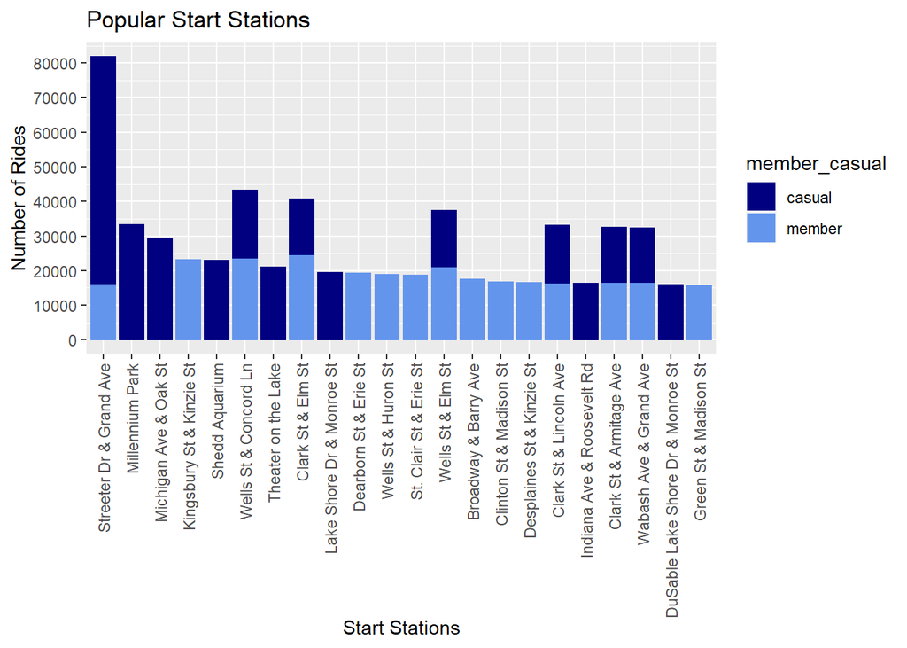

```r
ggplot(data=riders_start_stations,
       mapping= aes(x=reorder(start_station_name, -n), y=n,
                    fill=member_casual))+
  geom_bar(stat="identity") +
  theme(axis.text.x=element_text(angle=90, vjust=0.5, hjust=1))+
  labs(title= "Popular Start Stations", x="Start Stations",
       y="Number of Rides")+
  scale_y_continuous(breaks=seq(0,90000,10000))+
  scale_fill_manual(values=c("navyblue", "cornflowerblue"))
```

# **BIKE ROUTES MOST FREQUENTLY USED BY RIDERS**

There are 246,265 bike routes. A route is defined as the pairing of a start station and end station for each bike ride. This bar chart shows the most popular bike routes with the highest number of rides.

```r
cyclistic_data2 <-
  cyclistic_data %>%
  drop_na() %>%
  select(start_station_id, end_station_id, start_station_name,
         end_station_name, member_casual) %>%
  filter(start_station_id != end_station_id) %>%
  unite ("id_start_end",
         start_station_id, end_station_id, sep = "-") %>%
  unite ("name_start_end",
         start_station_name, end_station_name, sep = "-") %>%
  count(id_start_end, name_start_end, member_casual) %>%
  arrange(-n)
```

```r
cyclistic_data3 <- cyclistic_data2 %>%
                   top_n(10)
knitr::kable(cyclistic_data3, "pipe")
```

| id_start_end | name_start_end | member_casual | n |
| --- | --- | --- | --- |
| KA1503000014-KA1504000076 | Ellis Ave & 60th St-Ellis Ave & 55th St | member | 4082 |
| KA1504000076-KA1503000014 | Ellis Ave & 55th St-Ellis Ave & 60th St | member | 3652 |
| 13022-13008 | Streeter Dr & Grand Ave-Millennium Park | casual | 3309 |
| KA1503000014-KA1503000071 | Ellis Ave & 60th St-University Ave & 57th St | member | 3109 |
| KA1503000071-KA1503000014 | University Ave & 57th St-Ellis Ave & 60th St | member | 3010 |
| 13008-13022 | Millennium Park-Streeter Dr & Grand Ave | casual | 2927 |
| 15544-13022 | Shedd Aquarium-Streeter Dr & Grand Ave | casual | 2822 |
| 13300-13022 | Lake Shore Dr & Monroe St-Streeter Dr & Grand Ave | casual | 2811 |
| 13300-13022 | DuSable Lake Shore Dr & Monroe St-Streeter Dr & Grand Ave | casual | 2736 |
| 13022-13042 | Streeter Dr & Grand Ave-Michigan Ave & Oak St | casual | 2478 |

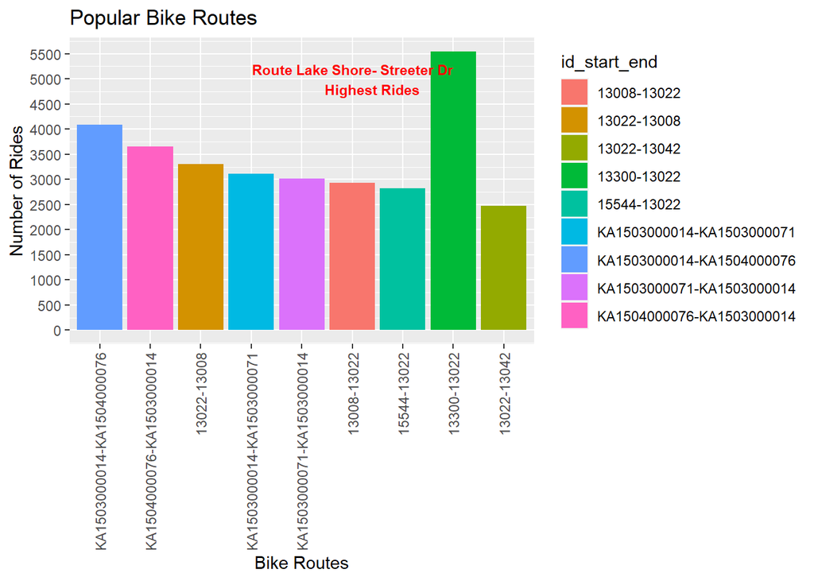

```r
ggplot(data=cyclistic_data3,
       mapping= aes(x=reorder(id_start_end, -n), y=n,
                    fill=id_start_end))+
  geom_bar(stat="identity") +
  theme(axis.text.x=element_text(angle=90, vjust=0.5, hjust=1))+
  labs(title= "Popular Bike Routes", x="Bike Routes",
       y="Number of Rides")+
  scale_y_continuous(breaks=seq(0,6000,500))+
  annotate("text", x="13008-13022", y=5000, label="Route Lake Shore- Streeter Dr
           Highest Rides", color="red", fontface="bold", size=3)
```

# **SEASON WITH HIGHEST NUMBER OF RIDES**

This Scatter Plot displays number of rides by month for both casual and member riders. The summer season in Chicago, June to September had the highest number of rides. This is highlighted in the chart by creating an annotation of a yellow rectangle.

The data type of column started_datetime is POSIXct and Double which is a DateTime

```r
class(cyclistic_data$started_datetime)
```

```
## [1] "POSIXct" "POSIXt"
```

```r
typeof(cyclistic_data$started_datetime)
```

```
## [1] "double"
```

Data frame copy is created called cyclistic_data5

```r
cyclistic_data5 <- cyclistic_data
```

Month name for column started_datetime is included in the data frame

```r
cyclistic_data5$month_name <-
  month(ymd_hms(cyclistic_data5$started_datetime),
        label=TRUE, abbr=FALSE)
```

```r
season_rides <- cyclistic_data5 %>%
                count(month_name, member_casual) %>%
                arrange(-n)
```

```r
knitr::kable(season_rides, "pipe")
```

| month_name | member_casual | n |
| --- | --- | --- |
| July | casual | 438441 |
| August | casual | 409598 |
| September | member | 388476 |
| August | member | 387848 |
| July | member | 376400 |
| October | member | 370097 |
| June | casual | 367281 |
| September | casual | 361175 |
| June | member | 355229 |
| May | member | 271737 |
| October | casual | 255264 |
| May | casual | 254767 |
| November | member | 250541 |
| April | member | 198607 |
| December | member | 176040 |
| March | member | 143205 |
| April | casual | 135643 |
| November | casual | 105972 |
| March | casual | 83509 |
| January | member | 78047 |
| December | casual | 69135 |
| February | member | 38995 |
| January | casual | 17953 |
| February | casual | 10029 |

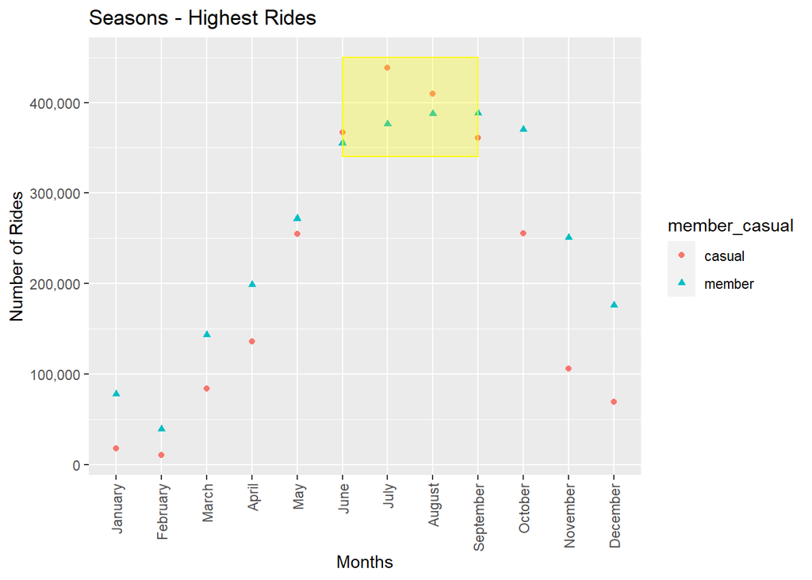

```r
ggplot(data=season_rides)+
  geom_point(mapping =aes(x=month_name, y=n, color=member_casual,
                          shape=member_casual))+
  geom_smooth(mapping =aes(x=month_name, y=n))+
  theme(axis.text.x=element_text(angle=90, vjust=0.5, hjust=1))+
  labs(title= "Seasons - Highest Rides", x="Months",
       y="Number of Rides")+
  scale_y_continuous(labels=comma) +
  annotate("rect", xmin="June", xmax="September", ymin=340000, ymax=450000,
           fill="yellow", color="yellow", alpha=0.3)
```

# **DAYS WITH HIGHEST NUMBER OF RIDES**

This Scatter Plot displays number of rides taken for each day of the week during the year 2021 for both casual and member riders.

The name of the day for each date in the column started_datetime has been included in the data frame.

The size and shape of the data points for member riders are different from the casual riders.

```r
cyclistic_data5$day_name <-
  wday(ymd_hms(cyclistic_data5$started_datetime),
        label=TRUE, abbr=FALSE)
```

```r
day_rides <- cyclistic_data5 %>%
             count(day_name, member_casual) %>%
             arrange(-n)
```

```r
knitr::kable(day_rides, "pipe")
```

| day_name | member_casual | n |
| --- | --- | --- |
| Saturday | casual | 553656 |
| Sunday | casual | 477308 |
| Wednesday | member | 472559 |
| Tuesday | member | 461134 |
| Thursday | member | 447235 |
| Friday | member | 441939 |
| Saturday | member | 428243 |
| Monday | member | 412116 |
| Sunday | member | 371996 |
| Friday | casual | 361067 |
| Monday | casual | 284134 |
| Thursday | casual | 283737 |
| Wednesday | casual | 276691 |
| Tuesday | casual | 272174 |

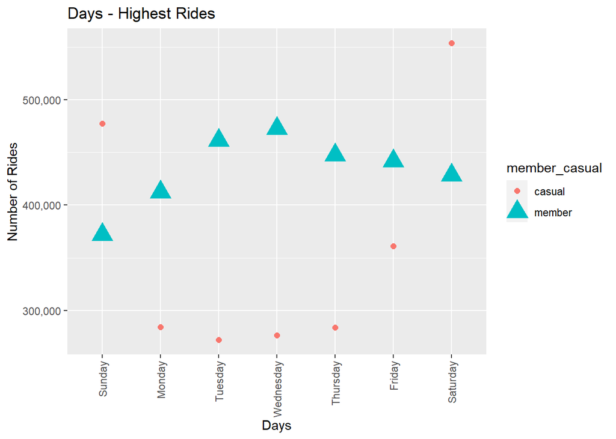

```r
ggplot(data=day_rides)+
  geom_point(mapping =aes(x=day_name, y=n, color=member_casual,
                          shape=member_casual, size=member_casual))+
  theme(axis.text.x=element_text(angle=90, vjust=0.5, hjust=1))+
  labs(title= "Days - Highest Rides", x="Days",
       y="Number of Rides")+
  scale_y_continuous(labels=comma)
```

# **TIMES WITH HIGHEST NUMBER OF RIDES**

This Scatter Plot displays number of rides by the time of day for both casual and member riders, during the year 2021.

Time by hour for column started_datetime is included in the data frame.

The geom_smooth function is used to show the regression line and patterns in the data.

The facet_wrap function is used to display separate plots for member and casual riders which are subsets of the main dataset.

```r
cyclistic_data5$hours <-
  hour(ymd_hms(cyclistic_data5$started_datetime))
```

```r
time_of_rides <- cyclistic_data5 %>%
                 count(hours, member_casual) %>%
                 arrange(-n)
```

```r
knitr::kable(time_of_rides, "pipe")
```

| hours | member_casual | n |
| --- | --- | --- |
| 17 | member | 317113 |
| 18 | member | 268810 |
| 16 | member | 254992 |
| 17 | casual | 234804 |
| 18 | casual | 212186 |
| 16 | casual | 203674 |
| 15 | member | 198894 |
| 19 | member | 192317 |
| 15 | casual | 187124 |
| 12 | member | 178795 |
| 14 | casual | 177024 |
| 13 | member | 176115 |
| 14 | member | 172820 |
| 13 | casual | 172049 |
| 8 | member | 171715 |
| 19 | casual | 165000 |
| 12 | casual | 160721 |
| 11 | member | 153783 |
| 7 | member | 148403 |
| 11 | casual | 134895 |
| 20 | member | 130198 |
| 9 | member | 129593 |
| 10 | member | 127944 |
| 20 | casual | 121097 |
| 10 | casual | 103827 |
| 21 | casual | 102903 |
| 21 | member | 96132 |
| 22 | casual | 95457 |
| 6 | member | 81088 |
| 9 | casual | 75615 |
| 22 | member | 73774 |
| 23 | casual | 73497 |
| 8 | casual | 63048 |
| 0 | casual | 53419 |
| 23 | member | 51113 |
| 7 | casual | 46360 |
| 1 | casual | 38951 |
| 0 | member | 32739 |
| 5 | member | 29782 |
| 6 | casual | 25513 |
| 2 | casual | 25347 |
| 1 | member | 21635 |
| 3 | casual | 13961 |
| 5 | casual | 12432 |
| 2 | member | 12319 |
| 4 | casual | 9863 |
| 4 | member | 8058 |
| 3 | member | 7090 |

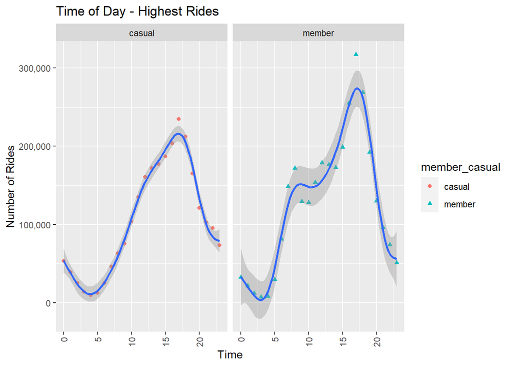

```r
ggplot(data=time_of_rides)+
  geom_point(mapping =aes(x=hours, y=n, color=member_casual,
                          shape=member_casual))+
  geom_smooth(mapping =aes(x=hours, y=n),
              method="gam", formula=y~s(x))+
  theme(axis.text.x=element_text(angle=90, vjust=0.5, hjust=1))+
  labs(title= "Time of Day - Highest Rides", x="Time",
       y="Number of Rides")+
  scale_y_continuous(labels=comma)+
  facet_wrap(~member_casual)
```